# Computing_Assignment_2

## EE 679 Speech Processing

## Computing Assignment 2: Linear predictive analysis and synthesis

## 12D020030

```python
%matplotlib inline
from __future__ import division
import numpy as np
from math import pi
import matplotlib.pyplot as plt
from scipy import signal
from scipy.io.wavfile import write
import scipy.io.wavfile as wav
```

**A. Synthesized vowel:** Consider the synthesized vowel /a/ (formants: 730, 1090, 2440 Hz; bandwidths: 50 Hz) at two fundamental frequencies: 120 Hz, 300 Hz. Sampling rate = 8 kHz. Using a 30 ms Hamming window, implement LP analysis on a single segment using LP orders 2, 4, 6, 8, 10 using the Levinson algorithm. Compute the gain, and plot the LP spectrum magnitude (i.e. the dB magnitude frequency response of the estimated all-pole filter) for each order "p". Superimpose each plot on the original 6-pole spectral envelope with the discrete harmonic components shown. Comment on the characteristics of the spectral approximations of different orders

```
Gain for /a/ of F0 = 120 Hz for LP order  2  is  7.72713023704
LP coefficients for the same are
[ 1.          1.45847659 -0.92856296  0.          0.          0.          0.
  0.          0.          0.          0.        ]
```

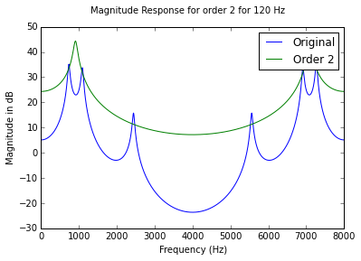

```
Gain for /a/ of F0 = 300 Hz for LP order  2  is  10.6906840267
LP coefficients for the same are
[ 1.          1.22042859 -0.70856644  0.          0.          0.          0.
  0.          0.          0.          0.        ]
```

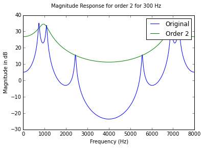

```
Gain for /a/ of F0 = 120 Hz for LP order  4  is  6.83262248964
LP coefficients for the same are
[ 1.          1.86124002 -1.88882732  0.95156231 -0.36663528  0.          0.
  0.          0.          0.          0.        ]
```

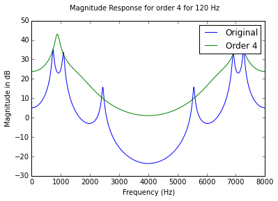

```
Gain for /a/ of F0 = 300 Hz for LP order  4  is  7.93547110956
LP coefficients for the same are
[ 1.          1.15612874 -1.08766141  0.74790288 -0.66919285  0.          0.
  0.          0.          0.          0.        ]
```

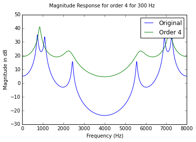

```
Gain for /a/ of F0 = 120 Hz for LP order  6  is  2.48760368184
LP coefficients for the same are
[ 1.          2.29907577 -3.13324673  3.06239042 -3.03866636  2.17074247
 -0.92203558  0.          0.          0.          0.        ]
```

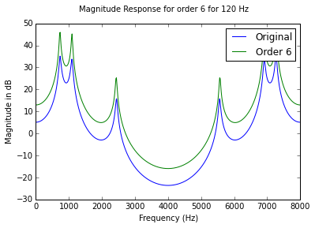

```
Gain for /a/ of F0 = 300 Hz for LP order  6  is  5.01533049361
LP coefficients for the same are
[ 1.          1.94430618 -2.37072056  2.26593671 -2.30313792  1.54633438
 -0.57993024  0.          0.          0.          0.        ]
```

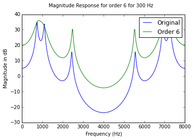

```
Gain for /a/ of F0 = 120 Hz for LP order  8  is  2.48621737896
LP coefficients for the same are
[ 1.          2.27138923 -3.05548256  2.9415115  -2.90521303  2.03479659
 -0.81018801 -0.06141069  0.01362095  0.          0.        ]
```

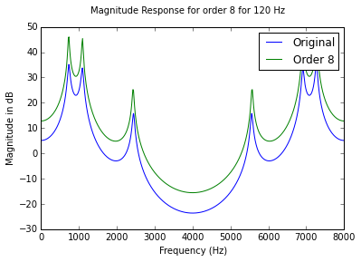

```
Gain for /a/ of F0 = 300 Hz for LP order  8  is  4.65816030674
LP coefficients for the same are
[ 1.          1.82304463 -1.88576907  1.3740693  -1.26548048  0.48506443
  0.41445089 -0.66976705  0.19950299  0.          0.        ]
```

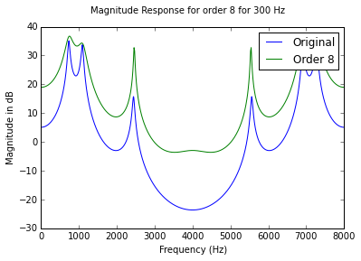

```
Gain for /a/ of F0 = 120 Hz for LP order  10  is  2.48542419889
LP coefficients for the same are
[ 1.          2.27084915 -3.05401413  2.95507986 -2.92232633  2.04283512
 -0.80244174 -0.06758627  0.03462962 -0.02697864  0.01913781]
```

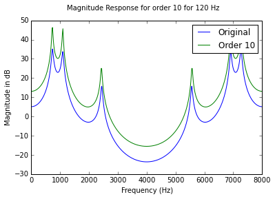

```
Gain for /a/ of F0 = 300 Hz for LP order  10  is  4.50153057742
LP coefficients for the same are
[ 1.          1.81918572 -1.86170519  1.21104444 -1.08579223  0.44447811
  0.26141407 -0.52049725 -0.08397963  0.33939044 -0.23822877]
```

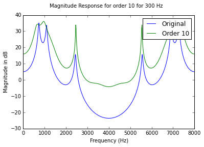

```python
B = 50
Fs = 8000
duration = 50/1000		#50 ms sound suration

def vowel(F0, F1, F2, F3):
	r = np.exp(-B*pi/Fs)	#Pole radius
	theta = [2*pi*F1/Fs, 2*pi*F2/Fs, 2*pi*F3/Fs]
	time = np.linspace(0, duration, duration*Fs)
	a1 = [1, -r*np.exp(-1j*theta[0])-r*np.exp(1j*theta[0]), r*r]
	a2 = [1, -r*np.exp(-1j*theta[1])-r*np.exp(1j*theta[1]), r*r]
	a3 = [1, -r*np.exp(-1j*theta[2])-r*np.exp(1j*theta[2]), r*r]
	x = np.zeros(int(duration*Fs))
	y = np.zeros(int(duration*Fs))
	temp1 = np.zeros(int(duration*Fs))
	temp2 = np.zeros(int(duration*Fs))
	for i in range(0, int(duration*F0)):
		x[i*int(np.floor(Fs/F0))] = 1

	temp1[0] = x[0]
	temp1[1] = x[1] - a1[1].real*temp1[0]	# a1[0] not written since a1[0] = 1
	for i in range(2, int(duration*Fs)):
			temp1[i] = x[i] - a1[1].real*temp1[i-1] - a1[2].real*temp1[i-2]

	temp2[0] = temp1[0]
	temp2[1] = temp1[1] - a2[1].real*temp2[0]	# a2[0] not written since a2[0] = 1
	for i in range(2, int(duration*Fs)):
			temp2[i] = temp1[i] - a2[1].real*temp2[i-1] - a2[2].real*temp2[i-2]

	y[0] = temp2[0]
	y[1] = temp2[1] - a3[1].real*y[0]	# a3[0] not written since a3[0] = 1
	for i in range(2, int(duration*Fs)):
			y[i] = temp2[i] - a3[1].real*y[i-1] - a3[2].real*y[i-2]

	w = np.linspace(0, 2*pi, Fs/2);
	z = np.exp(-1*1j*w);
	H1 = 1/(a1[0] + a1[1].real*z + a1[2]*z*z);
	H2 = 1/(a2[0] + a2[1].real*z + a2[2]*z*z);
	H3 = 1/(a3[0] + a3[1].real*z + a3[2]*z*z);
	H = H1*H2*H3
	return (y, H)

def LPanalysis(signal, p, windowLength):	#p = LP order
	#Windowing
	duration = signal.shape[-1]
	window = signal[(duration-int((windowLength)*Fs))/2.0:(duration+int((windowLength)*Fs))/2.0]*np.hamming(windowLength*Fs);
	R = np.correlate(signal,signal, mode = 'full')	#Autocorrelation
	R = R[-(len(signal)):len(R)];	#Keep autocorrelation values for positive values of i in summation(x[n]x[n-i])

	#Levinson Algorithm
	E = np.zeros(p+1);	#Vector to store error values
	a = np.zeros((p+1,p+1));
	G = np.zeros(p+1);
	E[0] = R[0];	#Initial Condition
	for i in range(1, p+1):		# 1 <= i <= p
		temp = 0;
		for j in range(1, i):	# 1 <= j <= i-1
			temp = temp + a[i-1][j] * R[i-j];
		k = (R[i] - temp)/E[i-1];
		a[i][i] = k;
		for j in range(1, i):	# 1<=j<=i-1
			a[i][j] = a[i-1][j] - k * a[i-1][i-j];
		E[i] = (1 - (k*k)) * E[i-1];
		G[i] = np.sqrt(E[i]);
		a[i][0] = 1;
	return(G, a);

a120, H120 = vowel(120, 730, 1090, 2440);
a300, H300 = vowel(300, 730, 1090, 2440);

windowLength = .03		#30 ms
G1, a1 = LPanalysis(a120, 10, windowLength);
G2, a2 = LPanalysis(a300, 10, windowLength);
P = [2,4,6,8,10];

for p in P:
	print("Gain for /a/ of F0 = 120 Hz for LP order ",p," is ", G1[p]);
	print("LP coefficients for the same are");
	print(a1[p]);
	a1[p][1:len(a1[p])] = -a1[p][1:len(a1[p])]
	w1, h1 = signal.freqz(G1[p], a1[p], None, 1);
	fig = plt.figure()
	w = np.linspace(0, 2*pi, Fs/2);
	plt.plot(w*Fs/(2*pi), 20*np.log10(abs(H120)))
	plt.plot(w1*Fs/(2*pi), 20*np.log10(abs(h1)))
	fig.suptitle('Magnitude Response for order '+str(p)+' for 120 Hz')
	plt.ylabel('Magnitude in dB')
	plt.xlabel('Frequency (Hz)')
	plt.legend(['Original', 'Order '+str(p)])
	plt.show()

	print("Gain for /a/ of F0 = 300 Hz for LP order ",p," is ", G2[p]);
	print("LP coefficients for the same are");
	print(a2[p]);
	a2[p][1:len(a2[p])] = -a2[p][1:len(a2[p])]
	w2, h2 = signal.freqz(G2[p], a2[p], None, 1);
	fig = plt.figure()
	w = np.linspace(0, 2*pi, Fs/2);
	plt.plot(w*Fs/(2*pi), 20*np.log10(abs(H300)))
	plt.plot(w2*Fs/(2*pi), 20*np.log10(abs(h2)))
	fig.suptitle('Magnitude Response for order '+str(p)+ ' for 300 Hz')
	plt.ylabel('Magnitude in dB')
	plt.xlabel('Frequency (Hz)')
	plt.legend(['Original', 'Order '+str(p)])
	plt.show()
```

We can see that the estimated LPC spectrum approximates the real signal spectrum better with increasing LPC order. The LPC spectrum tends to converge towards the signal spectrum with increasing order. This is because increasing LPC order means more poles in the tranfer function and hence more variability.

Also we see that the LPC sprectrum approximation is better in case of 120 Hz signal as compared to the 300 Hz signal.

**B. Natural speech:** Consider the speech signal in “machali.wav” (male voice), sampled at 8 kHz. Consider the following signal segments in the final word “pani”: (1) /a/ (first half); (2) /n/; (3) /I/; and (4) /s/ in the word “uska”. Use PRAAT to extract the above segments to separate .wav files for further analyses as below. (Note: for /s/, 16 kHz sampled audio is better.)  
**Question 1.** Compute and plot the narrowband spectrum using a Hamming window of duration = 30 ms before and after pre-emphasis.

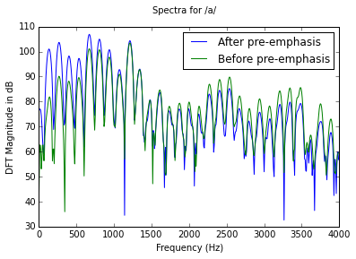

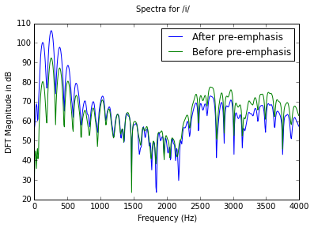

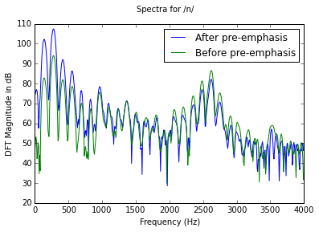

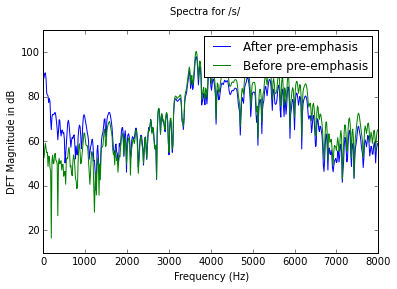

```python
def preEmphasis(x):
    a = 0.985;
    y = np.zeros(len(x));
    for i in range(1, len(x)):
        y[i] = x[i] - a*x[i-1];
    return y

def NarrowBandSpectrum(x, Fs, windowLength):
    window = x[int(len(x)/2)-int(windowLength/2*Fs):int(len(x)/2)+int(windowLength/2*Fs)] * np.hamming(windowLength*Fs);
    fourierTransform = np.fft.fft(window, 1024);
    frequency = np.fft.fftfreq(fourierTransform.shape[-1], 1/float(Fs))
    return fourierTransform, frequency

#Reading the wav files of the four segments
FsA, signalA = wav.read('a.wav');
FsI, signalI = wav.read('i.wav');
FsN, signalN = wav.read('n.wav');
FsS, signalS = wav.read('s.wav');

#Pre-emphasis
preEmphasizedA = preEmphasis(signalA);
preEmphasizedI = preEmphasis(signalI);
preEmphasizedN = preEmphasis(signalN);
preEmphasizedS = preEmphasis(signalS);

#Narrow Band Spectrum before pre-emphasis
preEmphasizedSpectrumA, frequency1A = NarrowBandSpectrum(signalA, FsA, .03);
preEmphasizedSpectrumI, frequency1I = NarrowBandSpectrum(signalI, FsI, .03);
preEmphasizedSpectrumN, frequency1N = NarrowBandSpectrum(signalN, FsN, .03);
preEmphasizedSpectrumS, frequency1S = NarrowBandSpectrum(signalS, FsS, .03);

#Narrow Band Spectrum after pre-emphasis
SpectrumA, frequency2A = NarrowBandSpectrum(preEmphasizedA, FsA, .03);
SpectrumI, frequency2I = NarrowBandSpectrum(preEmphasizedI, FsI, .03);
SpectrumN, frequency2N = NarrowBandSpectrum(preEmphasizedN, FsN, .03);
SpectrumS, frequency2S = NarrowBandSpectrum(preEmphasizedS, FsS, .03);

fig = plt.figure()
plt.plot(frequency1A[:int(len(frequency1A)/2)], 20*np.log10(np.abs(preEmphasizedSpectrumA[:len(preEmphasizedSpectrumA)/2])))
plt.plot(frequency2A[:int(len(frequency2A)/2)], 20*np.log10(np.abs(SpectrumA[:len(SpectrumA)/2])))
fig.suptitle('Spectra for /a/')
plt.ylabel('DFT Magnitude in dB')
plt.xlabel('Frequency (Hz)')
plt.legend(['After pre-emphasis', 'Before pre-emphasis'])
plt.show()

fig = plt.figure()
plt.plot(frequency1I[:int(len(frequency1I)/2)], 20*np.log10(np.abs(preEmphasizedSpectrumI[:len(preEmphasizedSpectrumI)/2])))
plt.plot(frequency2I[:int(len(frequency2I)/2)], 20*np.log10(np.abs(SpectrumI[:len(SpectrumI)/2])))
fig.suptitle('Spectra for /i/')
plt.ylabel('DFT Magnitude in dB')
plt.xlabel('Frequency (Hz)')
plt.legend(['After pre-emphasis', 'Before pre-emphasis'])
plt.show()

fig = plt.figure()
plt.plot(frequency1N[:int(len(frequency1N)/2)], 20*np.log10(np.abs(preEmphasizedSpectrumN[:len(preEmphasizedSpectrumN)/2])))
plt.plot(frequency2N[:int(len(frequency2N)/2)], 20*np.log10(np.abs(SpectrumN[:len(SpectrumN)/2])))
fig.suptitle('Spectra for /n/')
plt.ylabel('DFT Magnitude in dB')
plt.xlabel('Frequency (Hz)')
plt.legend(['After pre-emphasis', 'Before pre-emphasis'])
plt.show()

fig = plt.figure()
plt.plot(frequency1S[:int(len(frequency1S)/2)], 20*np.log10(np.abs(preEmphasizedSpectrumS[:len(preEmphasizedSpectrumS)/2])))
plt.plot(frequency2S[:int(len(frequency2S)/2)], 20*np.log10(np.abs(SpectrumS[:len(SpectrumS)/2])))
fig.suptitle('Spectra for /s/')
plt.ylabel('DFT Magnitude in dB')
plt.xlabel('Frequency (Hz)')
plt.legend(['After pre-emphasis', 'Before pre-emphasis'])
plt.show()
```

**Question 2** Using a 30 ms Hamming window centered in the segment of the waveform (pre-emphasised for the voiced sounds):

(a) Compute the autocorrelation coefficients required for LPC calculation at various p = 4,6,8,10,12,20. Use the Levinson algorithm to compute the LP coefficients from the autocorrelation coefficients. Show the pole-zero plots of the estimated all-pole filter for p=6,10.

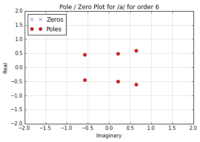

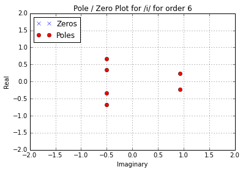

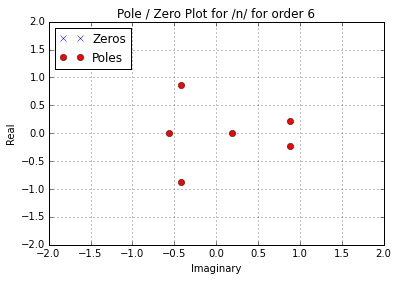

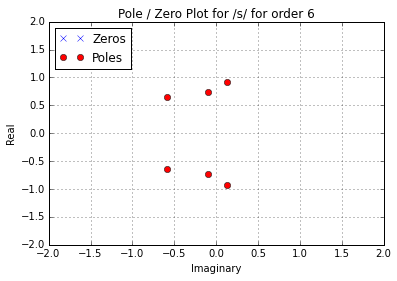

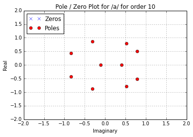

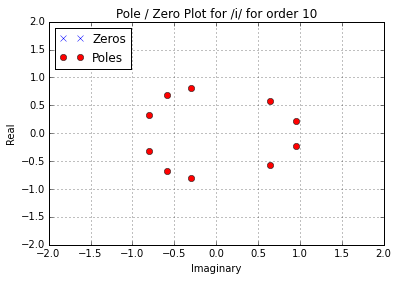

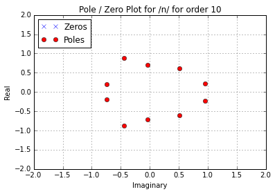

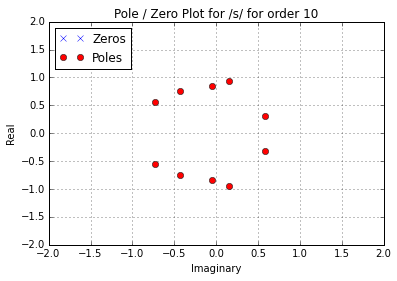

```python
def poleZeroPlot(b,a, phone):
    a[1:len(a)] = -a[1:len(a)];
    b=[b]
    z, p, k = signal.tf2zpk(b, a)
    p = p[p!=0]
    fig = plt.figure()
    plt.plot(np.real(z), np.imag(z), 'xb')
    plt.plot(np.real(p), np.imag(p), 'or')
    plt.ylim((-2.0, 2.0))
    plt.xlim((-2.0,2.0))
    plt.legend(['Zeros', 'Poles'], loc=2)
    plt.title('Pole / Zero Plot for /'+phone+'/ for order '+str(len(p)))
    plt.ylabel('Real')
    plt.xlabel('Imaginary')
    plt.grid()

#LP Analysis
windowLength = 0.03;
GA, aA = LPanalysis(preEmphasizedA, 20, windowLength);
GI, aI = LPanalysis(preEmphasizedI, 20, windowLength);
GN, aN = LPanalysis(preEmphasizedN, 20, windowLength);
GS, aS = LPanalysis(preEmphasizedS, 20, windowLength);

# Pole-zero plot
poleZeroPlot(GA[6], aA[6], 'a')
poleZeroPlot(GI[6], aI[6], 'i')
poleZeroPlot(GN[6], aN[6], 'n')
poleZeroPlot(GS[6], aS[6], 's')
poleZeroPlot(GA[10], aA[10], 'a')
poleZeroPlot(GI[10], aI[10], 'i')
poleZeroPlot(GN[10], aN[10], 'n')
poleZeroPlot(GS[10], aS[10], 's')
```

(b) Compute the gain and plot the LPC spectrum magnitude (i.e. the dB magnitude frequency response of the estimated all-pole filter) for each order "p". Superimpose each plot on the narrowband dB magnitude spectrum of part 1 (after pre-emphasis). Comment on the characteristics of the spectra